# AMA7 : GAM fits for hirsutism data

Cecilia, Rudio and Gerard

2023-12-06

```
##  Treatment      FGm0            FGm3             FGm6            FGm12
##  0:23      Min.   :14.57   Min.   : 4.381   Min.   : 1.786   Min.   :-1.163
##  1:26      1st Qu.:16.23   1st Qu.: 9.557   1st Qu.: 7.202   1st Qu.: 5.093
##  2:24      Median :17.65   Median :12.643   Median :10.286   Median : 7.524
##  3:26      Mean   :18.57   Mean   :13.084   Mean   :10.853   Mean   : 8.911
##            3rd Qu.:20.17   3rd Qu.:16.219   3rd Qu.:14.204   3rd Qu.:12.101
##            Max.   :28.36   Max.   :25.637   Max.   :23.411   Max.   :22.759
##
##     SysPres         DiaPres          weight           height
##  Min.   : 88.0   Min.   :46.00   Min.   : 41.00   Min.   :1.480
##  1st Qu.:110.0   1st Qu.:65.00   1st Qu.: 57.00   1st Qu.:1.580
##  Median :115.0   Median :70.00   Median : 64.00   Median :1.610
##  Mean   :115.9   Mean   :70.04   Mean   : 68.06   Mean   :1.613
##  3rd Qu.:120.0   3rd Qu.:75.00   3rd Qu.: 74.50   3rd Qu.:1.650
##  Max.   :162.0   Max.   :95.00   Max.   :113.00   Max.   :1.800
##  NA's   :8       NA's   :8       NA's   :8        NA's   :8
```

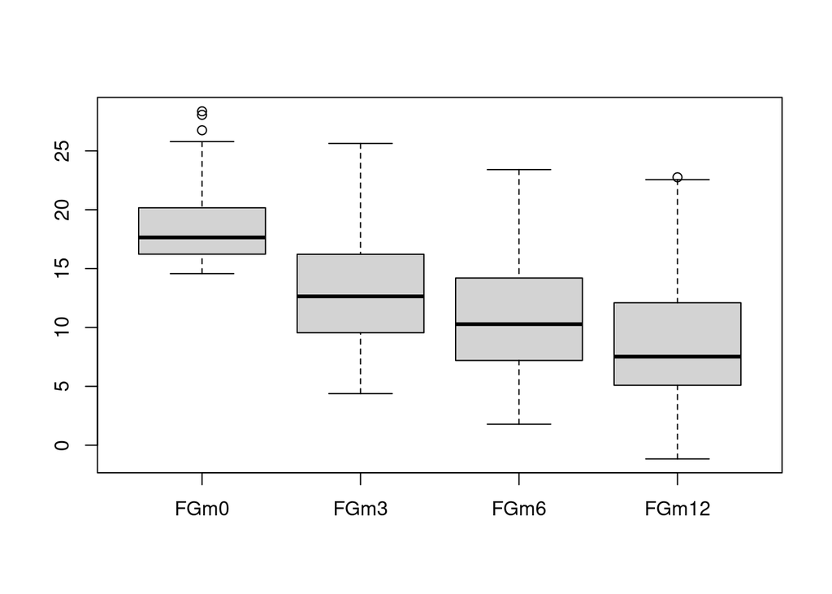

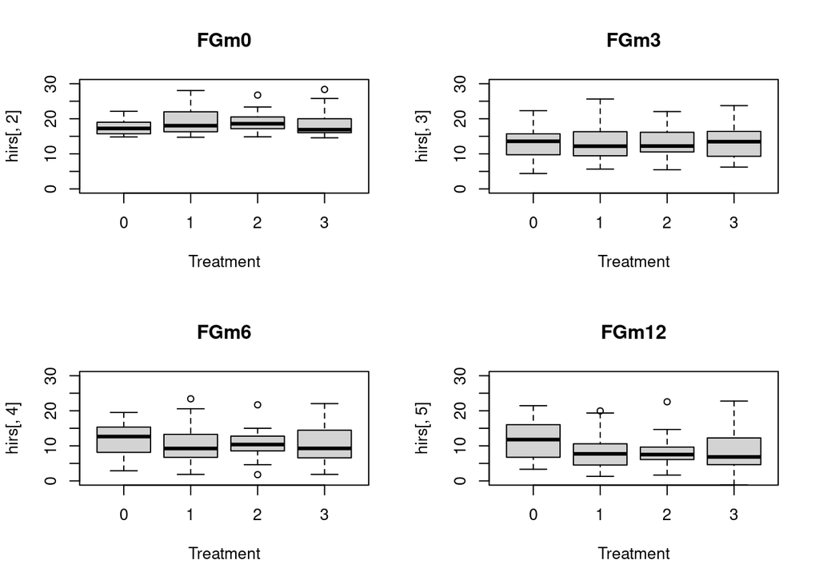

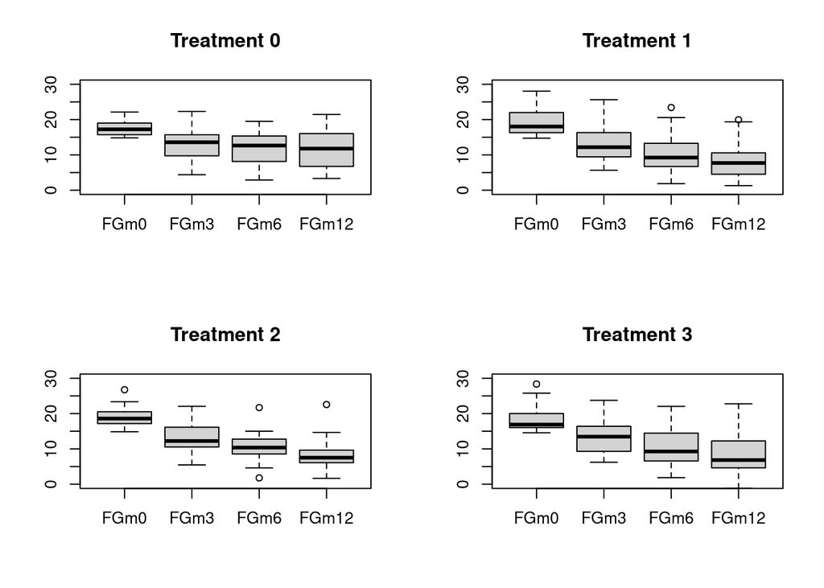

The following boxplots indicate the distribution of the records for thr FG values at different times and for different treatments. For instance, as a quick summary, for early stages of FG values there is a larger quantity of records for treatment. The lowest median lies for treatment 3 and the largest whiskers for treatment 1 and 3. Both treatment 2 and 3 include outliers. For FG values for month 3 all box heights appear very equal between treatments being treatment 2 the one with the lowest median and treatment 1 the one with the longest whiskers. Box heights differ for FG values for month 6 being treatment 3 the one with the highest box height and 2 the lowest. Treatment 1 and 2 both appear to have outliers and treatment 0 appears to have the highest mean above all treatments. Finally, for FG values for month 12 the highest median belongs to treatment 0 but the outliers lie in treatmetn 1 and 2. The highest variability for values ofr FGm12 lie for treatment 3. For the second batch of boxplots, it can be seen how the PG values decrease as month 12 approaches for all values, being Treatment 2 the one with the highest decrease between month 0 and 12. ##Modeling FGm12

First a model with all the variables and without smoothing is fitted.

```r
mod1 <- gam(FGm12~SysPres+DiaPres+weight+height+FGm0+Treatment, data = hirs)
summary(mod1)
```

```
##
## Family: gaussian
## Link function: identity
##
## Formula:
## FGm12 ~ SysPres + DiaPres + weight + height + FGm0 + Treatment
##
## Parametric coefficients:
##             Estimate Std. Error t value Pr(>|t|)
## (Intercept) 19.49686   14.85245   1.313 0.192945
## SysPres     -0.07570    0.05194  -1.458 0.148787
## DiaPres      0.03525    0.07115   0.495 0.621652
## weight       0.02768    0.04425   0.626 0.533308
## height      -8.71024    9.08570  -0.959 0.340540
## FGm0         0.59983    0.16862   3.557 0.000626 ***
## Treatment1  -4.33022    1.48110  -2.924 0.004471 **
## Treatment2  -4.31441    1.49589  -2.884 0.005012 **
## Treatment3  -3.94666    1.44364  -2.734 0.007668 **
## ---
## Signif. codes:  0 '***' 0.001 '**' 0.01 '*' 0.05 '.' 0.1 ' ' 1
##
##
## R-sq.(adj) =   0.17   Deviance explained = 24.4%
## GCV = 25.139  Scale est. = 22.653    n = 91
```

```r
mod1s <- gam(FGm12~s(SysPres)+s(DiaPres)+s(weight)+s(height)+s(FGm0)+Treatment, data = hirs)
summary(mod1s)
```

```
##
## Family: gaussian
## Link function: identity
##
## Formula:
## FGm12 ~ s(SysPres) + s(DiaPres) + s(weight) + s(height) + s(FGm0) +
##     Treatment
##
## Parametric coefficients:
##             Estimate Std. Error t value Pr(>|t|)
## (Intercept)   12.477      0.985  12.667  < 2e-16 ***
## Treatment1    -4.868      1.405  -3.465 0.000876 ***
## Treatment2    -4.576      1.418  -3.227 0.001847 **
## Treatment3    -4.154      1.383  -3.005 0.003601 **
## ---
## Signif. codes:  0 '***' 0.001 '**' 0.01 '*' 0.05 '.' 0.1 ' ' 1
##
## Approximate significance of smooth terms:
##              edf Ref.df     F p-value
## s(SysPres) 1.000  1.000 3.015 0.08653 .
## s(DiaPres) 1.956  2.464 1.191 0.40264
## s(weight)  1.000  1.000 1.146 0.28770
## s(height)  1.000  1.000 1.454 0.23159
## s(FGm0)    6.114  7.238 3.798 0.00143 **
## ---
## Signif. codes:  0 '***' 0.001 '**' 0.01 '*' 0.05 '.' 0.1 ' ' 1
##
## R-sq.(adj) =  0.288   Deviance explained = 39.9%
## GCV =  23.31  Scale est. = 19.45     n = 91
```

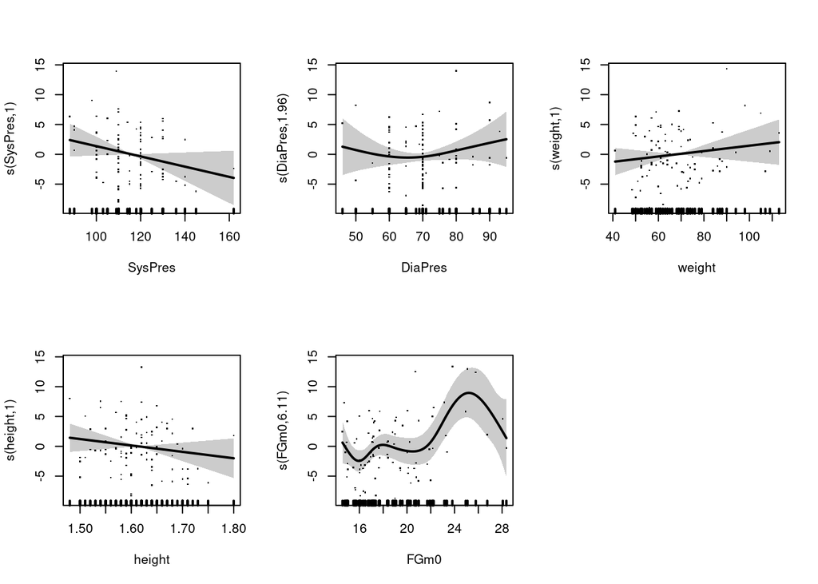

```r
plot(mod1s,pages=1,residuals=TRUE, shade=TRUE, cex=2, lwd=2)
```

As a result of this model it can be seen that again there isthe FGm0 variable significant, and also the intercept.

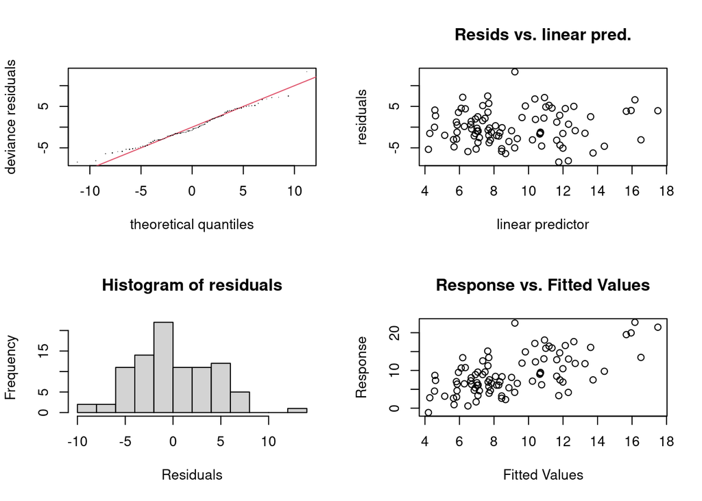

```
##
## Method: GCV   Optimizer: magic
## Smoothing parameter selection converged after 22 iterations.
## The RMS GCV score gradient at convergence was 8.714651e-07 .
## The Hessian was positive definite.
## Model rank =  49 / 49
##
## Basis dimension (k) checking results. Low p-value (k-index<1) may
## indicate that k is too low, especially if edf is close to k'.
##
##              k'  edf k-index p-value
## s(SysPres) 9.00 1.00    1.09    0.78
## s(DiaPres) 9.00 1.96    1.06    0.69
## s(weight)  9.00 1.00    1.10    0.78
## s(height)  9.00 1.00    0.87    0.18
## s(FGm0)    9.00 6.11    1.12    0.81
```

```r
par(mfrow = c(2,2))
gam.check(mod1s)
```

It can be clearly seen that the residuals have a parabolic shape, therefore sqrt the FGm12 in order to see if the residuals distribution improves is a choice.

```r
mod1sqrts <- gam(sqrt(FGm12)~s(SysPres)+s(DiaPres)+s(weight)+s(height)+s(FGm0)+Treatment, data = hirs)
summary(mod1sqrts)
```

```
##
## Family: gaussian
## Link function: identity
##
## Formula:
## sqrt(FGm12) ~ s(SysPres) + s(DiaPres) + s(weight) + s(height) +
##     s(FGm0) + Treatment
##
## Parametric coefficients:
##             Estimate Std. Error t value Pr(>|t|)
## (Intercept)   3.4436     0.1673  20.585  < 2e-16 ***
## Treatment1   -0.7914     0.2392  -3.308  0.00145 **
## Treatment2   -0.7234     0.2401  -3.013  0.00354 **
## Treatment3   -0.6382     0.2394  -2.666  0.00943 **
## ---
## Signif. codes:  0 '***' 0.001 '**' 0.01 '*' 0.05 '.' 0.1 ' ' 1
##
## Approximate significance of smooth terms:
##              edf Ref.df     F p-value
## s(SysPres) 1.000  1.000 1.891 0.17323
## s(DiaPres) 1.998  2.514 0.726 0.41395
## s(weight)  1.295  1.526 0.588 0.64854
## s(height)  1.596  1.974 0.525 0.62459
## s(FGm0)    6.235  7.326 3.208 0.00406 **
## ---
## Signif. codes:  0 '***' 0.001 '**' 0.01 '*' 0.05 '.' 0.1 ' ' 1
##
## R-sq.(adj) =  0.257   Deviance explained = 38.4%
## GCV = 0.67521  Scale est. = 0.55424   n = 90
```

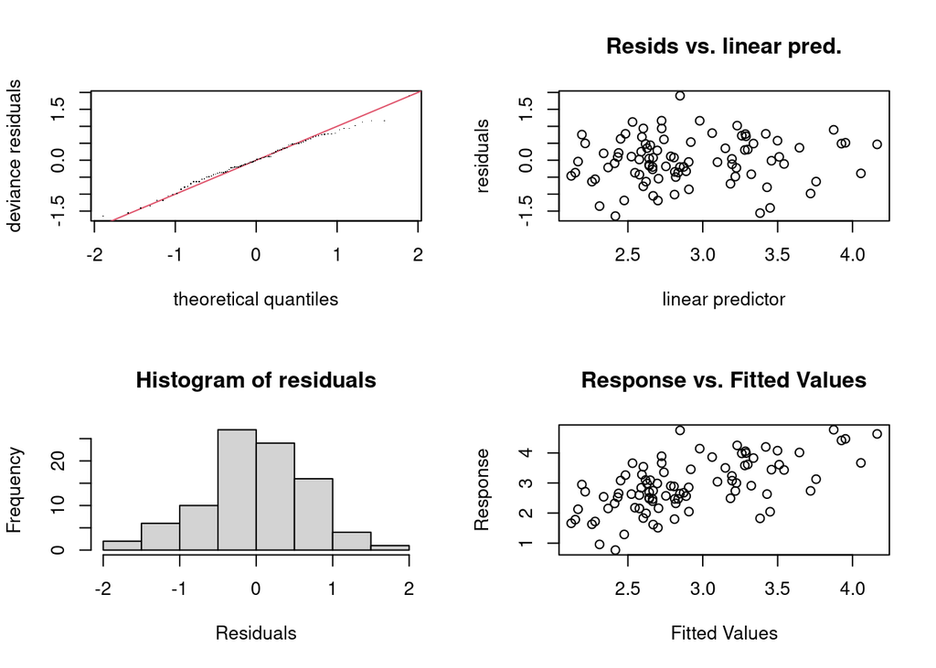

```
##
## Method: GCV   Optimizer: magic
## Smoothing parameter selection converged after 33 iterations.
## The RMS GCV score gradient at convergence was 1.071339e-07 .
## The Hessian was positive definite.
## Model rank =  49 / 49
##
## Basis dimension (k) checking results. Low p-value (k-index<1) may
## indicate that k is too low, especially if edf is close to k'.
##
##              k'  edf k-index p-value
## s(SysPres) 9.00 1.00    1.03   0.655
## s(DiaPres) 9.00 2.00    1.06   0.680
## s(weight)  9.00 1.30    1.11   0.800
## s(height)  9.00 1.60    0.87   0.095 .
## s(FGm0)    9.00 6.24    1.08   0.735
## ---
## Signif. codes:  0 '***' 0.001 '**' 0.01 '*' 0.05 '.' 0.1 ' ' 1
```

```r
par(mfrow = c(2,2))
gam.check(mod1sqrts)
```

Looking at the plots for the sqrt model,it can be seen an improvement in the plots. First, the residuals follow a normal distribution. The parabolic pattern there was in the resids vs linear pred is lost.

```r
mod1sqrts.1 <- gam(sqrt(FGm12)~s(FGm0)+Treatment, data = hirs)
summary(mod1sqrts.1)
```

```
##
## Family: gaussian
## Link function: identity
##
## Formula:
## sqrt(FGm12) ~ s(FGm0) + Treatment
##
## Parametric coefficients:
##             Estimate Std. Error t value Pr(>|t|)
## (Intercept)   3.4146     0.1624  21.021  < 2e-16 ***
## Treatment1   -0.8100     0.2251  -3.598 0.000528 ***
## Treatment2   -0.7135     0.2290  -3.116 0.002478 **
## Treatment3   -0.6015     0.2248  -2.676 0.008882 **
## ---
## Signif. codes:  0 '***' 0.001 '**' 0.01 '*' 0.05 '.' 0.1 ' ' 1
##
## Approximate significance of smooth terms:
##           edf Ref.df    F p-value
## s(FGm0) 5.936  7.069 4.21 0.00044 ***
## ---
## Signif. codes:  0 '***' 0.001 '**' 0.01 '*' 0.05 '.' 0.1 ' ' 1
##
## R-sq.(adj) =  0.255   Deviance explained = 32.4%
## GCV = 0.64291  Scale est. = 0.57773   n = 98
```

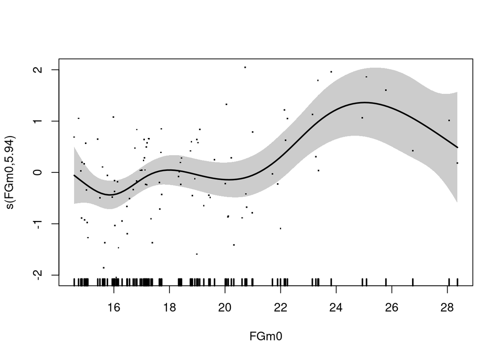

```r
plot(mod1sqrts.1,pages=1,residuals=TRUE, shade=TRUE, cex=2, lwd=2)
```

A new model is fitted including DiaPres variables as it was one of the highest edf values in the smoothed initial model, for sake of argumentation.

```r
mod1sqrts.3 <- gam(sqrt(FGm12)~s(FGm0)+s(DiaPres)+Treatment, data = hirs)
summary(mod1sqrts.3)
```

```
##
## Family: gaussian
## Link function: identity
##
## Formula:
## sqrt(FGm12) ~ s(FGm0) + s(DiaPres) + Treatment
##
## Parametric coefficients:
##             Estimate Std. Error t value Pr(>|t|)
## (Intercept)   3.4374     0.1659  20.722  < 2e-16 ***
## Treatment1   -0.8226     0.2377  -3.461 0.000877 ***
## Treatment2   -0.7245     0.2382  -3.042 0.003209 **
## Treatment3   -0.5852     0.2281  -2.566 0.012229 *
## ---
## Signif. codes:  0 '***' 0.001 '**' 0.01 '*' 0.05 '.' 0.1 ' ' 1
##
## Approximate significance of smooth terms:
##              edf Ref.df     F p-value
## s(FGm0)    6.373  7.491 3.326 0.00275 **
## s(DiaPres) 2.043  2.570 0.976 0.52524
## ---
## Signif. codes:  0 '***' 0.001 '**' 0.01 '*' 0.05 '.' 0.1 ' ' 1
##
## R-sq.(adj) =  0.253   Deviance explained = 34.8%
## GCV = 0.64721  Scale est. = 0.55792   n = 90
```

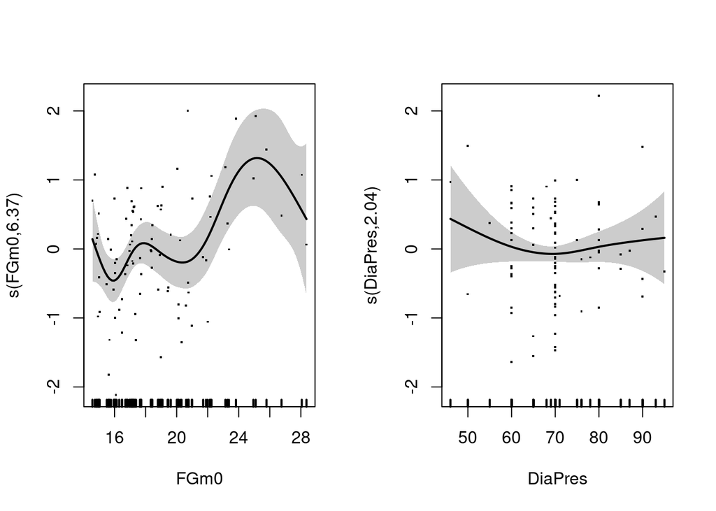

```r
plot(mod1sqrts.3,pages=1,residuals=TRUE, shade=TRUE, cex=2, lwd=2)
```

As a next step the interaction between the variables and the treatment is added

```r
mod1sqrts.2 <- gam(sqrt(FGm12)~s(FGm0,by=Treatment), data = hirs)
summary(mod1sqrts.2)
```

```
##
## Family: gaussian
## Link function: identity
##
## Formula:
## sqrt(FGm12) ~ s(FGm0, by = Treatment)
##
## Parametric coefficients:
##             Estimate Std. Error t value Pr(>|t|)
## (Intercept)  2.72796    0.09036   30.19   <2e-16 ***
## ---
## Signif. codes:  0 '***' 0.001 '**' 0.01 '*' 0.05 '.' 0.1 ' ' 1
##
## Approximate significance of smooth terms:
##                      edf Ref.df     F p-value
## s(FGm0):Treatment0 5.200  5.977 2.101 0.05995 .
## s(FGm0):Treatment1 3.762  4.610 2.270 0.05267 .
## s(FGm0):Treatment2 1.000  1.000 1.088 0.30001
## s(FGm0):Treatment3 3.017  3.747 4.004 0.00574 **
## ---
## Signif. codes:  0 '***' 0.001 '**' 0.01 '*' 0.05 '.' 0.1 ' ' 1
##
## R-sq.(adj) =  0.248   Deviance explained = 34.8%
## GCV = 0.68094  Scale est. = 0.5838    n = 98
```

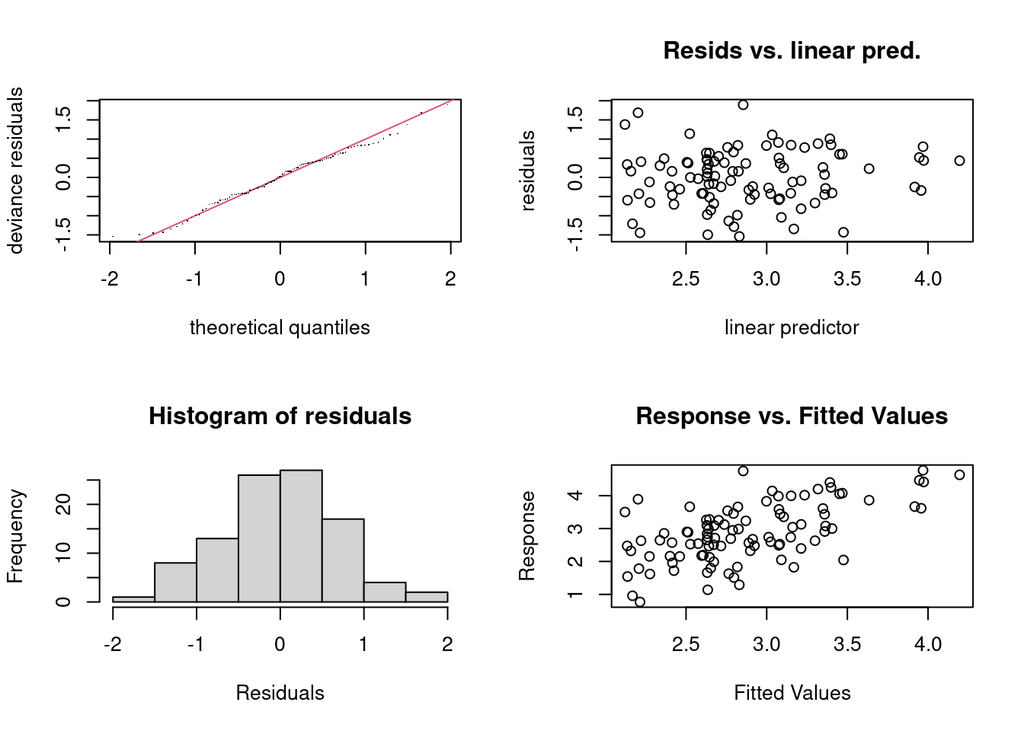

```
##
## Method: GCV   Optimizer: magic
## Smoothing parameter selection converged after 18 iterations.
## The RMS GCV score gradient at convergence was 5.311263e-08 .
## The Hessian was positive definite.
## Model rank =  37 / 37
##
## Basis dimension (k) checking results. Low p-value (k-index<1) may
## indicate that k is too low, especially if edf is close to k'.
##
##                      k'  edf k-index p-value
## s(FGm0):Treatment0 9.00 5.20    0.97    0.42
## s(FGm0):Treatment1 9.00 3.76    0.97    0.43
## s(FGm0):Treatment2 9.00 1.00    0.97    0.38
## s(FGm0):Treatment3 9.00 3.02    0.97    0.34
```

```r
par(mfrow = c(2,2))
gam.check(mod1sqrts.2)
```

```r
mod1sqrts.4 <- gam(sqrt(FGm12)~s(DiaPres,by=Treatment)+s(FGm0, by=Treatment), data = hirs)
summary(mod1sqrts.4)
```

```
##
## Family: gaussian
## Link function: identity
##
## Formula:
## sqrt(FGm12) ~ s(DiaPres, by = Treatment) + s(FGm0, by = Treatment)
##
## Parametric coefficients:
##             Estimate Std. Error t value Pr(>|t|)
## (Intercept)  2.88340    0.09044   31.88   <2e-16 ***
## ---
## Signif. codes:  0 '***' 0.001 '**' 0.01 '*' 0.05 '.' 0.1 ' ' 1
##
## Approximate significance of smooth terms:
##                         edf Ref.df     F p-value
## s(DiaPres):Treatment0 1.197  1.364 1.691  0.1582
## s(DiaPres):Treatment1 3.066  3.783 0.978  0.4898
## s(DiaPres):Treatment2 1.000  1.000 0.294  0.5896
## s(DiaPres):Treatment3 2.664  3.256 2.093  0.1360
## s(FGm0):Treatment0    1.604  1.999 0.811  0.4567
## s(FGm0):Treatment1    1.477  1.814 2.799  0.1243
## s(FGm0):Treatment2    1.000  1.000 0.792  0.3765
## s(FGm0):Treatment3    6.051  7.090 2.445  0.0258 *
## ---
## Signif. codes:  0 '***' 0.001 '**' 0.01 '*' 0.05 '.' 0.1 ' ' 1
##
## R-sq.(adj) =   0.25   Deviance explained = 40.3%
## GCV = 0.70977  Scale est. = 0.55946   n = 90
```

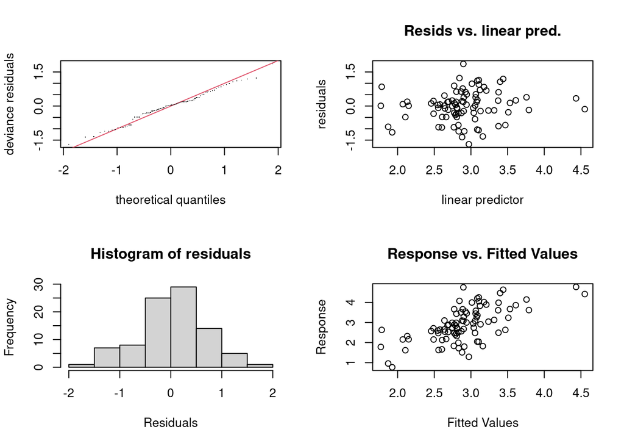

```
##
## Method: GCV   Optimizer: magic
## Smoothing parameter selection converged after 20 iterations.
## The RMS GCV score gradient at convergence was 6.383776e-08 .
## The Hessian was positive definite.
## Model rank =  73 / 73
##
## Basis dimension (k) checking results. Low p-value (k-index<1) may
## indicate that k is too low, especially if edf is close to k'.
##
##                         k'  edf k-index p-value
## s(DiaPres):Treatment0 9.00 1.20    1.01    0.49
## s(DiaPres):Treatment1 9.00 3.07    1.01    0.44
## s(DiaPres):Treatment2 9.00 1.00    1.01    0.52
## s(DiaPres):Treatment3 9.00 2.66    1.01    0.49
## s(FGm0):Treatment0    9.00 1.60    1.08    0.80
## s(FGm0):Treatment1    9.00 1.48    1.08    0.76
## s(FGm0):Treatment2    9.00 1.00    1.08    0.78
## s(FGm0):Treatment3    9.00 6.05    1.08    0.80
```

```r
par(mfrow = c(2,2))
gam.check(mod1sqrts.4)
```

```r
anova(mod1sqrts.1, mod1sqrts.2,test='F')
```

```
## Analysis of Deviance Table
##
## Model 1: sqrt(FGm12) ~ s(FGm0) + Treatment
## Model 2: sqrt(FGm12) ~ s(FGm0, by = Treatment)
##   Resid. Df Resid. Dev     Df Deviance      F Pr(>F)
## 1    86.931     50.877
## 2    81.667     49.051 5.2645   1.8258 0.5941 0.7129
```

As the anova is not significant the simpler model is better, so the model without the interaction.

For the following anova test the two additional models are tested for sake of argumentation but the results are no better than models mode1sqrts.1 and mod1sqrts.2.

```r
anova(mod1sqrts.3, mod1sqrts.4,test='F')
```

```
## Analysis of Deviance Table
##
## Model 1: sqrt(FGm12) ~ s(FGm0) + s(DiaPres) + Treatment
## Model 2: sqrt(FGm12) ~ s(DiaPres, by = Treatment) + s(FGm0, by = Treatment)
##   Resid. Df Resid. Dev     Df Deviance      F Pr(>F)
## 1    75.939     43.285
## 2    67.693     39.688 8.2454   3.5971 0.7798 0.6254
```

```r
mod2sqrts.1 <- gam(sqrt(FGm12)~te(FGm0,DiaPres) + Treatment, data = hirs)
summary(mod2sqrts.1)
```

```
##
## Family: gaussian
## Link function: identity
##
## Formula:
## sqrt(FGm12) ~ te(FGm0, DiaPres) + Treatment
##
## Parametric coefficients:
##             Estimate Std. Error t value Pr(>|t|)
## (Intercept)   3.3973     0.1755  19.354  < 2e-16 ***
## Treatment1   -0.7265     0.2510  -2.895  0.00485 **
## Treatment2   -0.6751     0.2514  -2.685  0.00875 **
## Treatment3   -0.5682     0.2424  -2.344  0.02145 *
## ---
## Signif. codes:  0 '***' 0.001 '**' 0.01 '*' 0.05 '.' 0.1 ' ' 1
##
## Approximate significance of smooth terms:
##                  edf Ref.df     F p-value
## te(FGm0,DiaPres)   3      3 4.074 0.00944 **
## ---
## Signif. codes:  0 '***' 0.001 '**' 0.01 '*' 0.05 '.' 0.1 ' ' 1
##
## R-sq.(adj) =  0.139   Deviance explained = 19.7%
## GCV = 0.69715  Scale est. = 0.64292   n = 90
```

```r
mod2sqrts.2 <- gam(sqrt(FGm12)~te(FGm0,SysPres) + Treatment , data = hirs)
summary(mod2sqrts.2)
```

```
##
## Family: gaussian
## Link function: identity
##
## Formula:
## sqrt(FGm12) ~ te(FGm0, SysPres) + Treatment
##
## Parametric coefficients:
##             Estimate Std. Error t value Pr(>|t|)
## (Intercept)   3.3889     0.1733  19.552  < 2e-16 ***
## Treatment1   -0.7030     0.2481  -2.834  0.00577 **
## Treatment2   -0.6551     0.2479  -2.642  0.00985 **
## Treatment3   -0.5765     0.2430  -2.373  0.01996 *
## ---
## Signif. codes:  0 '***' 0.001 '**' 0.01 '*' 0.05 '.' 0.1 ' ' 1
##
## Approximate significance of smooth terms:
##                  edf Ref.df     F p-value
## te(FGm0,SysPres)   3      3 4.466 0.00587 **
## ---
## Signif. codes:  0 '***' 0.001 '**' 0.01 '*' 0.05 '.' 0.1 ' ' 1
##
## R-sq.(adj) =  0.149   Deviance explained = 20.7%
## GCV = 0.68863  Scale est. = 0.63507   n = 90
```

```r
mod2sqrts.3 <- gam(sqrt(FGm12)~te(FGm0,weight) + Treatment, data = hirs)
summary(mod2sqrts.3)
```

```
##
## Family: gaussian
## Link function: identity
##
## Formula:
## sqrt(FGm12) ~ te(FGm0, weight) + Treatment
##
## Parametric coefficients:
##             Estimate Std. Error t value Pr(>|t|)
## (Intercept)   3.4255     0.1724  19.875  < 2e-16 ***
## Treatment1   -0.7925     0.2439  -3.249  0.00168 **
## Treatment2   -0.6722     0.2491  -2.699  0.00846 **
## Treatment3   -0.6162     0.2381  -2.588  0.01144 *
## ---
## Signif. codes:  0 '***' 0.001 '**' 0.01 '*' 0.05 '.' 0.1 ' ' 1
##
## Approximate significance of smooth terms:
##                   edf Ref.df     F p-value
## te(FGm0,weight) 4.606  5.364 2.813  0.0175 *
## ---
## Signif. codes:  0 '***' 0.001 '**' 0.01 '*' 0.05 '.' 0.1 ' ' 1
##
## R-sq.(adj) =  0.166   Deviance explained = 23.8%
## GCV = 0.68798  Scale est. = 0.62219   n = 90
```

```r
mod2sqrts.4 <- gam(sqrt(FGm12)~te(FGm0,height) + Treatment , data = hirs)
summary(mod2sqrts.4)
```

```
##
## Family: gaussian
## Link function: identity
##
## Formula:
## sqrt(FGm12) ~ te(FGm0, height) + Treatment
##
## Parametric coefficients:
##             Estimate Std. Error t value Pr(>|t|)
## (Intercept)   3.4004     0.1703  19.962  < 2e-16 ***
## Treatment1   -0.7469     0.2421  -3.085  0.00279 **
## Treatment2   -0.6614     0.2431  -2.720  0.00797 **
## Treatment3   -0.5735     0.2413  -2.377  0.01982 *
## ---
## Signif. codes:  0 '***' 0.001 '**' 0.01 '*' 0.05 '.' 0.1 ' ' 1
##
## Approximate significance of smooth terms:
##                   edf Ref.df     F p-value
## te(FGm0,height) 4.891  5.668 2.779  0.0161 *
## ---
## Signif. codes:  0 '***' 0.001 '**' 0.01 '*' 0.05 '.' 0.1 ' ' 1
##
## R-sq.(adj) =  0.173   Deviance explained = 24.7%
## GCV = 0.68461  Scale est. = 0.61698   n = 90
```

```r
AIC(mod1sqrts.1,mod2sqrts.1,mod2sqrts.2,mod2sqrts.3,mod2sqrts.4)
```

```
##                    df      AIC
## mod1sqrts.1 10.935805 235.7395
## mod2sqrts.1  8.000005 224.3662
## mod2sqrts.2  8.000000 223.2601
## mod2sqrts.3  9.606258 222.8696
## mod2sqrts.4  9.890614 222.3660
```

Out of all these new fitted models, the best one is the model with Treatment, and a tensor of FGm0 and height, as it is the one with the lowest AIC.